# Final Presentation

12/13/2019

## Research Question

What positions on the Jeopardy board are most likely to be a Daily Double?

- By round
- By year

## Introduction

- Importance to the game
  - Arthur Chu (2014)
  - James Holzhauer (2019)
- Previous analyses
  - None have been presented across years
- Challenge of finding position
- Visual representation of results

## Methods

- Only included episodes from dates beyond November 26, 2001
- Finding x position of daily double (filtered to episodes with 12 categories)
- Finding y position of daily double (Weighted across missing values)

## Methods

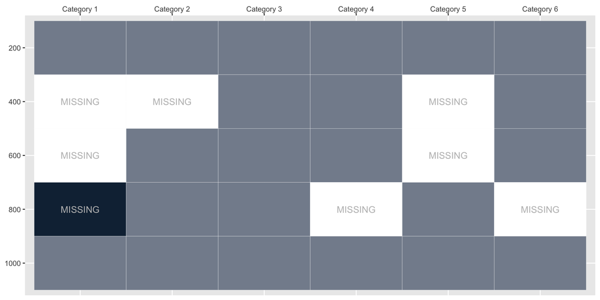

## Methods

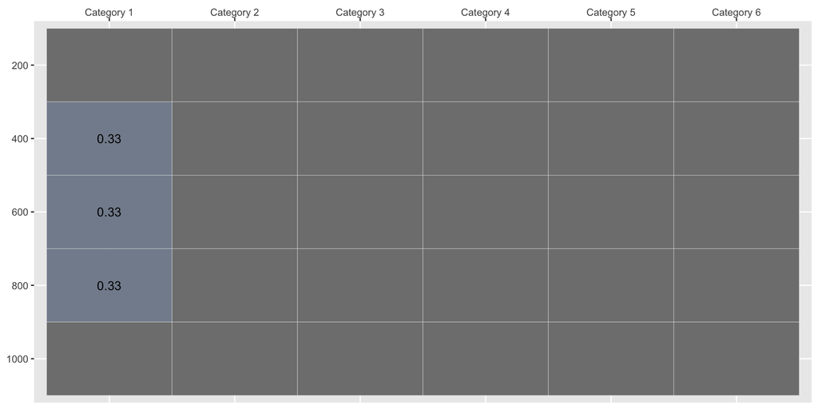

## Results

Flex Dashboard:

- Daily Double Round 1 since 2001
- Daily Double Round 2 since 2001
- Daily Double Location by year

## Conclusions

- Similar to previous analyses
  - https://flowingdata.com/2015/03/03/where-to-find-jeopardy-daily-doubles/
- Shift in location in 2016
  - Arthur Chu and subsequent analyses
- Future locations (pattern or random)

## Overview of Approach

1. Nest data by air date
2. Pull out subsets of that data
3. Modify subsets by:
   1. Adding additional information (i.e. weight, x/y position)
   2. Manipulating data (i.e. expanding, further subsetting)
4. Rejoin dataframes to get desired information
5. Create tidy dataset for plots

## Interesting Packages or Techniques

- Creating perfect data frame
  - Package: `tidyr`
  - Function(s): `expand()`
- Mapping
  - Package: `purrr`
  - Function(s): `map()`, `map2()`
- Joining
  - Package: `dplyr`
  - Function(s): `right_join()`, `full_join()`, `left_join()`
- Plotting
  - Package: `plotly`
  - Function(s): `plot_ly()`

## Examples

- Input
  - `categories_asked`: information about each episode

```r
mutate(categories_unique = map(data, ~ unique(select(., category)),
        categories_unique = map(categories_unique,
                            ~ rownames_to_column(., var = "x_pos")),
         perfect_pos = map2(categories_unique, categories_asked,
                            ~ full_join(.x, .y)),
         perfect_pos = map(perfect_pos,
                           ~ group_by(., round)),
         perfect_pos = map(perfect_pos,
                           ~ expand(., x_pos, value)))
```

- Output
  - `categories_unique`: x position assigned to each category
  - `perfect_pos`: perfect df for each game

## Examples

- Input
  - `dd_perfect`: perfect DD df
  - `dd_weight`: df containing the weight to be assiged to DD questions

```r
mutate(dd_perfect = map2(dd_perfect, dd_weight,
                ~ full_join(.x, .y, by = "category")),
       dd_perfect = map(dd_perfect,
                 ~ mutate(., daily_double = case_when(
                   is.na(daily_double) == TRUE ~ weight,
                   is.na(daily_double) == FALSE ~ daily_double))))
```

- Output
  - `dd_perfect`: perfect DD df with weights added

## Examples

```r
daily_double_year %>%
  unnest() %>%
  plot_ly(
    x = ~ x_pos,
    y = ~ y_pos,
    z = ~ Percent,
    frame = ~ year,
    hovertemplate = paste("Daily Double Percent: %{z:,}%<br>",
                          "<extra></extra>"),
    colors = "Blues",
    type = 'heatmap'
) %>%
  layout(title = list(text = ""),
         xaxis = list(title = "",
                      side = 'top'),
          yaxis = list(title = ""))
```

## Lessons Learned

1. Seemingly simple problems may not be simple to answer.
2. Pros/cons of `ggplot()` vs `plot_ly()`
3. Project organization and GitHub
4. Writing other code before data is completely clean is beneficial.